# Imputation of Data with Non-linear Associations

## Preface

### R packages

In this practical, a number of R packages are used. If any of them are not installed you can still follow the practical but will not be able to run all of the code. The packages used (with versions that were used to generate the solutions) are:

- `mice` (version: 3.4.0)
- `JointAI` (version: 0.5.1)
- `ggplot2` (version: 3.1.1)
- `reshape2` (version: 1.4.3)

### Help files

You can find help files for any function by adding a `?` before the name of the function.

Alternatively, you can look up the help pages online at https://www.rdocumentation.org/ or find the whole manual for a package at https://cran.r-project.org/web/packages/available_packages_by_name.html

### Dataset

For this practical, we will use a subset of the **NHANES** dataset that we have seen in the previous practicals. It contains only those cases that have observed `wgt` and some columns that are not needed were excluded.

To load this dataset, you can use the command `file.choose()` which opens the explorer and allows you to navigate to the location of the file `NHANES_for_practicals_2.RData` on your computer. If you know the path to the file, you can also use `load("<path>/NHANES_for_practicals_2.RData")`.

### Aim

The focus of this practical is the imputation of data that has features that require special attention.

In the interest of time, we will focus on these features and **abbreviate steps that are the same as in any imputation setting** (e.g., getting to know the data or checking that imputed values are realistic). **Nevertheless, these steps are of course required when analysing data in practice.**

Our aim is to fit the following **linear regression model for weight**:

```r
mod <- lm(wgt ~ gender + bili + age * (chol + HDL) + hgt)
```

We expect that the effects of cholesterol and HDL may differ with age, and, hence, include **interaction terms** between `age` and `chol` and `HDL`, respectively.

Additionally, we want to include the other variables in the dataset as auxiliary variables.

## Imputation using **mice**

When the analysis model of interest involves interaction terms between incomplete variables, **mice** has limited options to reduce the bias that may be introduced by naive handling of the missing values.

Use of the “Just Another Variable” approach can in some settings reduce bias. Alternatively, we can use passive imputation, i.e., calculate the interaction terms in each iteration of the MICE algorithm. Furthermore, predictive mean matching tends to lead to less bias than normal imputation models.

### Just Another Variable approach

#### Task 1

- Calculate the interaction terms in the incomplete data, and
- perform the setup-run of `mice()` without any iterations.

#### Solution 1

```r
# calculate the interaction terms
NHANES$agechol <- NHANES$age * NHANES$chol
NHANES$ageHDL <- NHANES$age * NHANES$HDL

# setup run
imp0 <- mice(NHANES, maxit = 0, defaultMethod = c('norm', 'logreg', 'polyreg', 'polr'))
```

#### Task 2

Apply the necessary change to the imputation method and predictor matrix.

Since the interaction terms are calculated from the orignal variables, these interaction terms should not be used to impute the original variables.

#### Solution 2

```r
meth <- imp0$method
pred <- imp0$predictorMatrix

# change imputation for "bili" to pmm (to prevent negative values)
meth["bili"] <- 'pmm'

# changes in predictor matrix to prevent that the original variables are
# imputed based on the interaction terms
pred["chol", "agechol"] <- 0
pred["HDL", "ageHDL"] <- 0
```

#### Task 3

Run the imputation using the **JAV approach**.

#### Solution 3

```r
# run imputation with the JAV approach
impJAV <- mice(NHANES, method = meth, predictorMatrix = pred,
                maxit = 10, m = 5)
```

#### Task 4

We skip the evaluation of convergence and investigation of the imputed values. With the settings given in the solution the chains have converged and distributions of the imputed values match the distributions of the observed data close enough.

- Analyse the imputed data and pool the results.

#### Solution 4

```r
miraJAV <- with(impJAV,
                lm(wgt  ~ gender + bili + age + chol + HDL + agechol + ageHDL + hgt))
summary(pool(miraJAV), conf.int = TRUE)
```

|  | estimate | std.error | statistic | df | p.value | 2.5 % | 97.5 % |
| --- | --- | --- | --- | --- | --- | --- | --- |
| (Intercept) | -109.5645322 | 20.32913675 | -5.389532 | 146.3969 | 1.180174e-07 | -149.7410231 | -69.38804125 |
| genderfemale | 4.2263417 | 1.90573084 | 2.217701 | 419.9645 | 2.710970e-02 | 0.4803823 | 7.97230105 |
| bili | -6.9222622 | 2.88573783 | -2.398784 | 242.5339 | 1.688480e-02 | -12.6065693 | -1.23795499 |
| age | 0.6696990 | 0.23745775 | 2.820287 | 164.9465 | 5.025411e-03 | 0.2008504 | 1.13854754 |
| chol | 9.9043097 | 2.10323672 | 4.709080 | 254.8903 | 3.386315e-06 | 5.7623749 | 14.04624452 |
| HDL | -21.8093086 | 6.29281295 | -3.465749 | 181.7386 | 5.832178e-04 | -34.2256772 | -9.39294002 |
| agechol | -0.1575460 | 0.04117781 | -3.825993 | 270.4782 | 1.500313e-04 | -0.2386158 | -0.07647625 |
| ageHDL | 0.1517674 | 0.12878041 | 1.178498 | 133.0101 | 2.392655e-01 | -0.1029551 | 0.40648992 |
| hgt | 99.7338715 | 9.31148880 | 10.710841 | 311.0457 | 0.000000e+00 | 81.4123999 | 118.05534310 |

### Passive Imputation

For the passive imputation, we can re-use the adjusted versions of `meth` and `pred` we created for the JAV approach, but additional changes to `meth` are necessary.

#### Task 1

Specify the new imputation method, i.e., adapt `meth` and save it as `methPAS`.

For passive imputation instead of an imputation method you need to specify the formula used to calculate the value that is imputed passively.

#### Solution 1

```r
# changes in imputation method for passive imputation
methPAS <- meth
methPAS[c("agechol", "ageHDL")] <- c("~I(age*chol)", "~I(age*HDL)")
```

#### Task 2

Run the imputation.

#### Solution 2

```r
# run imputation with passive imputation
impPAS <- mice(NHANES, method = methPAS, predictorMatrix = pred,
                maxit = 10, m = 5)
```

#### Task 3

We will again skip evaluation of convergence and investigation of the imputed values.

- Analyse the imputed data and pool the results.

#### Solution 3

```r
miraPAS <- with(impPAS,
                lm(wgt ~ gender + bili + age + chol + HDL + agechol + ageHDL + hgt))

summary(pool(miraPAS), conf.int = TRUE)
```

|  | estimate | std.error | statistic | df | p.value | 2.5 % | 97.5 % |
| --- | --- | --- | --- | --- | --- | --- | --- |
| (Intercept) | -105.8333905 | 19.64037230 | -5.388563 | 432.54573 | 1.169302e-07 | -144.43582617 | -67.23095473 |
| genderfemale | 3.8186069 | 1.93197262 | 1.976533 | 371.22481 | 4.872928e-02 | 0.01962443 | 7.61758941 |
| bili | -7.1258647 | 2.85258149 | -2.498041 | 373.55794 | 1.285850e-02 | -12.73499481 | -1.51673466 |
| age | 0.5631217 | 0.24463922 | 2.301846 | 96.70834 | 2.181819e-02 | 0.07756208 | 1.04868131 |
| chol | 9.0922860 | 2.10610272 | 4.317114 | 410.31447 | 1.961703e-05 | 4.95218848 | 13.23238346 |
| HDL | -21.6306560 | 6.46331890 | -3.346679 | 86.04418 | 8.892852e-04 | -34.47921461 | -8.78209741 |
| agechol | -0.1390985 | 0.04209951 | -3.304041 | 322.86465 | 1.032268e-03 | -0.22192252 | -0.05627452 |
| ageHDL | 0.1601340 | 0.12818361 | 1.249255 | 104.87624 | 2.122474e-01 | -0.09403389 | 0.41430193 |
| hgt | 100.0437431 | 9.32648868 | 10.726839 | 356.22287 | 0.000000e+00 | 81.70184331 | 118.38564284 |

## Imputation with **JointAI**

**JointAI** provides functions that allow to fit Bayesian regression models with incomplete covariates. The main functions are designed to resemble the standard functions to fit regression models with complete data.

For univariate outcomes the following functions are available:

- `lm_imp()`: for linear regression
- `glm_imp()`: for generalized linear regression (e.g., logistic, Gamma or Poisson)
- `clm_imp()`: for ordinal (cumulative logit) regression

### Specification of the analysis model

Similar to the complete data versions, the functions from **JointAI** take the following arguments:

| `formula` | model formula |
| --- | --- |
| `data` | original, incomplete dataset |
| `family` | for glm’s: the distribution family of the outcome (e.g., binomial() for a logistic model) |

#### Task 1

Specify the linear regression model with the model formula given above using `lm_imp()`. You need to specify the arguments `formula`, `data` and `n.iter`. Set `n.iter = 100` (we will learn about this argument further down).

#### Solution 1

```r
lm1 <- lm_imp(wgt ~ gender + bili + age * (chol + HDL) + hgt, data = NHANES,
               n.iter = 100)
```

```
## This is new software. Please report any bugs to the package maintainer.
```

#### Task 2

The result is an object of class `JointAI`, which contains the original data (`data`), information on the type of model (`call`, `analysis_type`, `models`, `fixed`, `random`, `hyperpars`, `scale_pars`) and MCMC sampling (`mcmc_settings`), the JAGS model (`model`) and MCMC sample (`MCMC`; if a sample was generated), the computational time (`time`) of the MCMC sampling, and some additional elements that are used by methods for objects of class `JointAI` but are typically not of interest for the user.

Check which imputation models were used in `lm1`.

The imputation model types are returned in the JointAI object under “models”.

#### Solution 2

```r
lm1$models
```

```
##    hgt   chol    HDL   bili
## "norm" "norm" "norm" "norm"
```

### Specification of the imputation models

Moreover, there are some arguments related to the imputation part of the model:

[output not shown]

Like in **mice** default imputation models are chosen based on the `class` of each of the incompete variables. The default choices for baseline (not time-varying) covariates are

| name | model | variable type |
| --- | --- | --- |
| `norm` | linear regression | continuous variables |
| `logit` | logistic regression | factors with two levels |
| `multilogit` | multinomial logit model | unordered factors with >2 levels |
| `cumlogit` | cumulative logit model | ordered factors with >2 levels |

Alternative imputation methods are available for continuous baseline covariates:

| name | model | variable type |
| --- | --- | --- |
| `lognorm` | normal regression of the log-transformed variable | right-skewed variables >0 |
| `gamma` | Gamma regression (with log-link) | right-skewed variables >0 |
| `beta` | beta regression (with logit-link) | continuous variables with values in [0, 1] |

#### Task 1

Re-fit the linear regression model, but now

- specify a log-normal or a gamma distribution for `bili`
- set the reference category to the largest group
- use the other variables that are in the data as auxiliary variables

To specify a non-default imputation method use the argument `models = c(bili = ...)`.

To set the respective largest group as reference category for all categorical variables use the argument `refcats = "largest"`.

Auxiliary variables need to be specified explicitely using the argument `auxvars`. It takes a vector of variable names (each of them in quotes).

#### Solution

```r
lm2 <- lm_imp(wgt ~ gender + bili + age * (chol + HDL) + hgt, data = NHANES,
               auxvars = c('educ', 'race', 'SBP', 'hypten', 'WC'),
               models = c(bili = 'lognorm'), refcats = 'largest',
               n.iter = 100)
```

```
## This is new software. Please report any bugs to the package maintainer.
```

```
## Note: ordered factors are included as dummy variables into the linear predictor (not as orthogonal polynomials).
```

### Specification of the MCMC settings

Specification of the basic settings for the MCMC sampling can be achieved using the following arguments:

| `n.chains` | number of MCMC chains |
| --- | --- |
| `n.adapt` | number of iterations used in the adaptive phase |
| `n.iter` | number of iterations per MCMC chain in the sampling phase |

**JointAI** has more arguments than the ones given above, but in this practical we focus only on the most important. You may find out more about all the arguments in the vignette on [MCMC Settings](https://nerler.github.io/JointAI/articles/MCMCsettings.html).

By default, `n.chains = 3`, `n.adapt = 100` and `n.iter = 0`.

It is usefull to use more than one chain to be able to evaluate convergence of the MCMC chains.

Samples in the adaptive phase are not used for the final MCMC sample. They are needed to optimize the MCMC sampler. When the number provided via the argument `n.adapt` is insufficient for this optimization a warning message will be printed. In simple models (e.g., linear regression) usually the default value of `n.adapt = 100` can be used.

The default value for `n.iter`, the number of iterations in the sampling phase is `0` (no MCMC sample will be created). The number of iterations that is needed depends on how complex the model and the data is and can range from somewhere as low as 100 up to several million.

In the following we will look at some criteria to determine if the number of MCMC samples that was used is sufficient.

### Evaluation of the MCMC sample

The first step after fitting a Bayesian model should be to confirm that the MCMC chains have converged. This can be done visually, using a traceplot (plotting the sampled values per parameter and chain accross iterations) or using the Gelman-Rubin criterion.

#### Task 1

Investigate convergence of `lm2` by creating a traceplot using the function `traceplot()`.

The plot should show a horizontal band without trends or patterns and the different chains should be mixed.

#### Solution 1

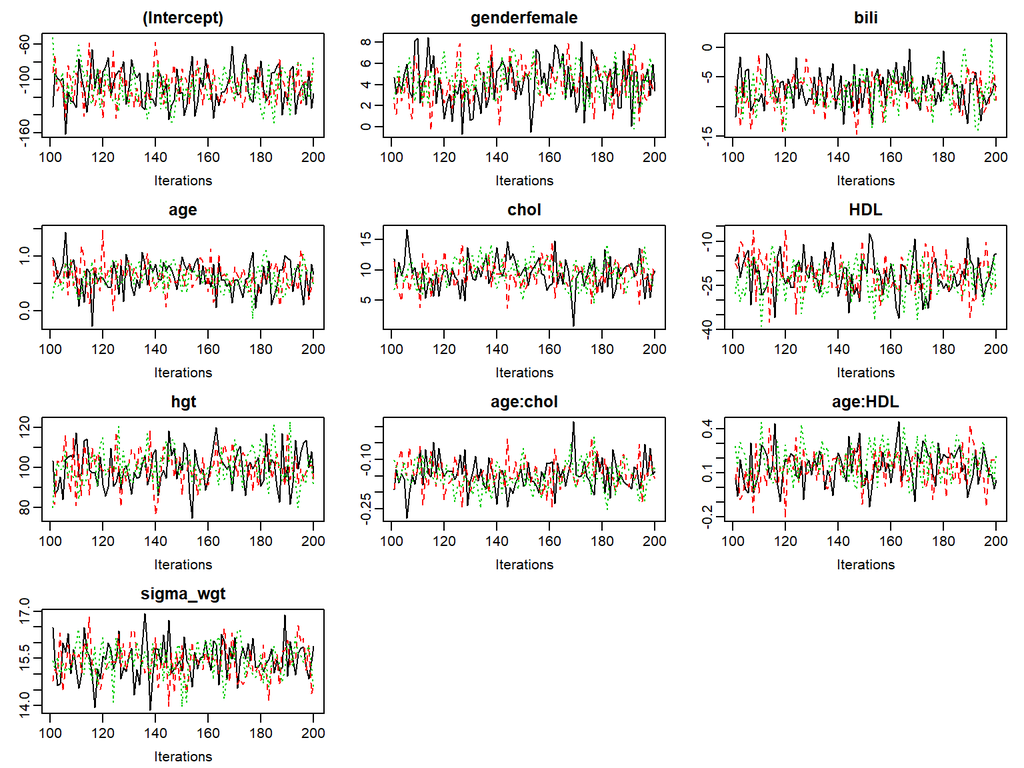

```r
traceplot(lm2)
```

#### Task 2

Investigate convergence of `lm2` using the Gelman-Rubin criterion, implemented in the function `GR_crit()`.

The upper limit of the confidenceinterval should not be much larger than 1.

#### Solution 2

```r
GR_crit(lm2)
```

```
## Potential scale reduction factors:
##
##              Point est. Upper C.I.
## (Intercept)       0.997      0.998
## genderfemale      1.013      1.022
## bili              1.003      1.020
## age               1.003      1.006
## chol              1.004      1.024
## HDL               1.017      1.072
## hgt               0.997      0.999
## age:chol          1.006      1.033
## age:HDL           1.032      1.121
## sigma_wgt         1.002      1.015
##
## Multivariate psrf
##
## 1.05
```

#### Coninue

When we are satisfied with the convergence of the MCMC chains we can take a look at the MCMC sample is precise enough. We can do this by comparing the Monte Carlo error (which describes the error made since we have just a finite sample) to the estimated standard deviation.

This is implemented in the function `MC_error()`.

#### Task 3

Calculate the Monte Carlo error for `lm2`.

#### Solution 3

```r
MC_error(lm2)
```

```
##                  est   MCSE     SD MCSE/SD
## (Intercept)  -107.09 1.4642 19.227   0.076
## genderfemale    4.23 0.1405  1.810   0.078
## bili           -7.29 0.1606  2.835   0.057
## age             0.62 0.0168  0.254   0.066
## chol            9.41 0.1908  2.300   0.083
## HDL           -21.96 0.3823  6.090   0.063
## hgt           100.03 0.4657  8.772   0.053
## age:chol       -0.15 0.0034  0.045   0.077
## age:HDL         0.15 0.0081  0.120   0.067
## sigma_wgt      15.42 0.0361  0.546   0.066
```

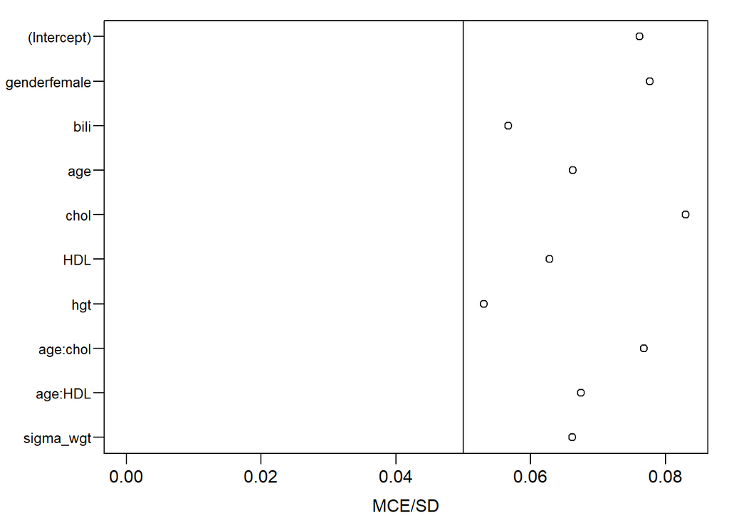

```r
par(mar = c(3.2, 5, 1, 1), mgp = c(2, 0.6, 0))
plot(MC_error(lm2))
```

### Results

#### Task

Get the summary of the model using the function `summary()`.

#### Solution

```r
summary(lm2)
```

```
##
##  Linear model fitted with JointAI
##
## Call:
## lm_imp(formula = wgt ~ gender + bili + age * (chol + HDL) + hgt,
##     data = NHANES, n.iter = 100, auxvars = c("educ", "race",
##         "SBP", "hypten", "WC"), refcats = "largest", models = c(bili = "lognorm"),
##     seed = 2019)
##
## Posterior summary:
##                  Mean      SD      2.5%   97.5% tail-prob. GR-crit
## (Intercept)  -107.089 19.2274 -143.4709 -70.979    0.00000   0.998
## genderfemale    4.233  1.8096    0.5265   7.740    0.02667   1.022
## bili           -7.293  2.8346  -13.2331  -1.600    0.01333   1.020
## age             0.623  0.2538    0.1003   1.060    0.01333   1.006
## chol            9.410  2.2999    4.8986  13.887    0.00000   1.024
## HDL           -21.957  6.0904  -34.6258 -10.238    0.00000   1.072
## hgt           100.031  8.7724   82.0921 117.586    0.00000   0.999
## age:chol       -0.147  0.0445   -0.2376  -0.054    0.00667   1.033
## age:HDL         0.148  0.1197   -0.0806   0.367    0.20667   1.121
##
## Posterior summary of residual std. deviation:
##           Mean    SD 2.5% 97.5% GR-crit
## sigma_wgt 15.4 0.546 14.3  16.5    1.02
##
##
## MCMC settings:
## Iterations = 101:200
## Sample size per chain = 100
## Thinning interval = 1
## Number of chains = 3
##
## Number of observations: 500
```

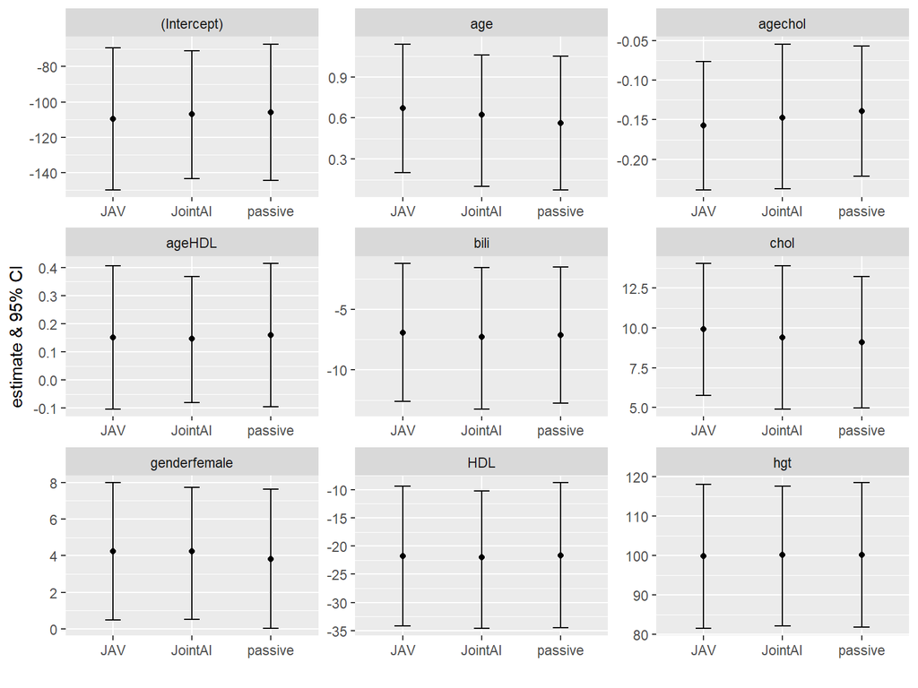

```r
resdat <- lapply(list(
  JAV = summary(pool(miraJAV), conf.int = TRUE)[, c('estimate', '2.5 %', '97.5 %')],
  passive = summary(pool(miraPAS), conf.int = TRUE)[, c('estimate', '2.5 %', '97.5 %')],
  JointAI = as.data.frame(summary(lm2)$stat[names(coef(lm2)), c(1, 3, 4)])
), function(x) {
  colnames(x) <- c('est', 'lo',  'up')
  x$variable <- gsub(":", "", rownames(x))
  x
  })


ggplot(reshape2::melt(resdat, id.vars = c('est', 'lo', 'up', 'variable')),
       aes(x = L1, y = est)) +
  geom_point() +
  geom_errorbar(aes(ymin = lo, ymax = up), width = 0.2) +
  facet_wrap('variable', scales = 'free') +
  xlab("") +
  ylab("estimate & 95% CI")
```

© Nicole Erler